- [Home](https://www.who.int/)/
- [News](https://www.who.int/news)/
- WHO releases new global lists of high-burden countries for TB, HIV-associated TB and drug-resistant TB

# WHO releases new global lists of high-burden countries for TB, HIV-associated TB and drug-resistant TB

17 June 2021

Departmental news

Reading time: 3 min (698 words)

The World Health Organization (WHO) today released updated global lists of high burden countries for tuberculosis (TB), HIV-associated TB and multidrug/rifampicin-resistant TB (MDR/RR-TB). The new lists are for 2021–2025 and replace those previously used between 2016 and 2020.

The lists provide a focus for global action on TB, HIV-associated TB and drug-resistant TB in the countries where progress is most needed to achieve the targets set in WHO’s End TB Strategy, the political declaration of the United Nations (UN) high-level meeting on TB held in 2018 and the UN Sustainable Development Goals (SDGs). They also help to build and sustain national political commitment and funding in the countries with the highest burden in terms of absolute numbers or severity and promote global monitoring of progress in a well-defined set of countries.

Following extensive consultation, the new lists have been defined using the same criteria as those used for the previous 2016-2020 lists, combined with the latest estimates (for 2019) of the incidence of TB, HIV-associated TB and rifampicin-resistant TB that were published in WHO’s *Global Tuberculosis Report 2020*.

The three lists, of 30 countries each, are all defined in the same way:

- the top 20 countries in terms of their estimated absolute number of new (incident) cases in 2019; plus
- the 10 countries with the most severe burden in terms of the incidence rate (new cases per 100 000 population in 2019) that are not already in the top 20, and that meet a minimum threshold in terms of their absolute number of cases (10 000 new cases per year for TB; and 1000 new cases per year for HIV-associated TB and rifampicin-resistant TB).

Each list accounts for 86-90% of the estimated global incidence.

The main changes compared with the previous lists for 2016-2020 are:

- **The 30 high TB burden countries:** Cambodia, the Russian Federation and Zimbabwe have transitioned out of the list; Gabon, Mongolia and Uganda have joined the list.
- **The 30 high TB/HIV burden countries:** Angola, Chad, Ghana and Papua New Guinea have transitioned out of the list; Gabon, Guinea, Philippines and the Russian Federation have joined the list.
- **The 30 high MDR/RR-TB burden countries.** Ethiopia, Kenya and Thailand have transitioned out of the list; Mongolia, Nepal and Zambia have joined the list.

WHO has officially communicated with the ministers of health of Cambodia, the Russian Federation and Zimbabwe, to inform them about their country’s transition out of the list of 30 high TB burden countries and to recognize their success in reducing the burden of TB disease in recent years. Between 2015 and 2019, incidence (per 100 000 population per year) fell by an estimated 22%, 25% and 18%, respectively, in the three countries.  
WHO is also establishing a “global TB watchlist”. This consists of the three countries transitioning out the global list of 30 high TB burden countries, since they still warrant continued attention and will remain a priority in terms of support from WHO. In future, other countries may be considered for inclusion on this watchlist – for example, based on evidence about the impact of the COVID-19 pandemic on TB services and disease burden. It is crucial that countries on the watchlist as well as mid- to low-incidence countries continue on their pathway to the 2030 targets, and then to pre-elimination and elimination.  
The context of the COVID-19 pandemic was considered prior to finalizing the updated global high-burden country lists. In particular, an assessment of whether the impact of the pandemic on TB incidence could plausibly affect the countries included in each list was done. Based on this analysis, it was concluded that it was unlikely that the COVID-19 pandemic would change the countries included in each list.

*The three global HBC lists for TB, TB/HIV and MDR/RR-TB to be used by WHO during the period 2021–2025, and their areas of overlap. Countries in the TB list are those within the red T-shaped border. Countries in the TB/HIV list are within the yellow border. Countries in the MDR/RR-TB list are within the blue border:*

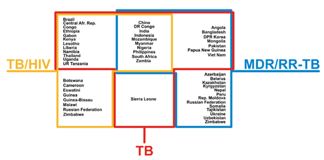

**Special Information Session:**  
A special EndTB Webinar will be held on 30 June at 13:00H to provide more information on the updated high burden country lists and implications.

Subscribe to our newsletters →

Related

- [WHO global lists of high burden countries for tuberculosis (TB), TB/HIV and multidrug/rifampicin-resistant TB (MDR/RR-TB)](https://cdn.who.int/media/docs/default-source/hq-tuberculosis/who_globalhbcliststb_2021-2025_backgrounddocument.pdf?sfvrsn=f6b854c2_9)
- [Accompanying slide-set](https://cdn.who.int/media/docs/default-source/hq-tuberculosis/globalhbclists_tb_2021_2025_slideset.pdf?sfvrsn=7fd1388a_7)